# Spatial_Modeling_Assignment

Julie Raiguel

February 15, 2018

## Question 1

Gather data and packages.

```r
library(vegan)
library(nlme)
source('https://raw.githubusercontent.com/dmcglinn/quant_methods/gh-pages/scripts/utility_functions.R')

data(BCI)
## UTM Coordinates (in metres)
BCI_xy = data.frame(x = rep(seq(625754, 626654, by=100), each=5), y = rep(seq(1011569,  1011969, by=100), len=50))
```

Look at data that is given and make sure the sites line up.

```r
BCI[6,1:2]
```

```
##   Abarema.macradenia Vachellia.melanoceras
## 6                  0                     0
```

```r
ncol(BCI)
```

```
## [1] 225
```

```r
nrow(BCI)
```

```
## [1] 50
```

```r
head(BCI_xy)
```

```
##        x       y
## 1 625754 1011569
## 2 625754 1011669
## 3 625754 1011769
## 4 625754 1011869
## 5 625754 1011969
## 6 625854 1011569
```

```r
nrow(BCI_xy)
```

```
## [1] 50
```

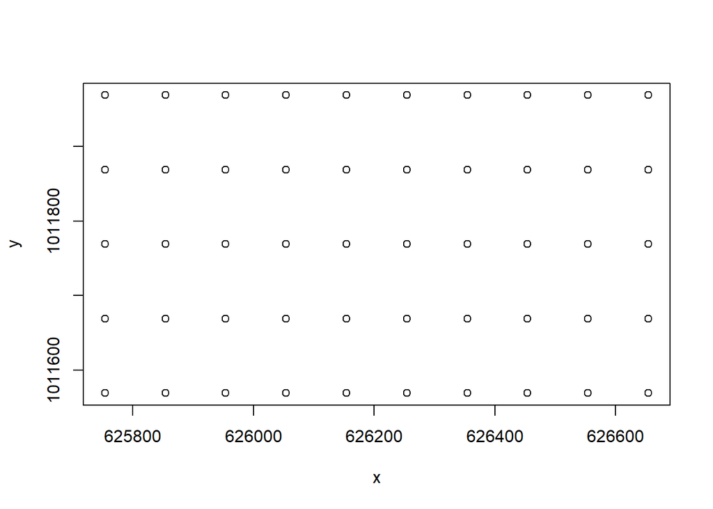

```r
plot(BCI_xy)
```

See if there is variation in the number of the species at the sites.

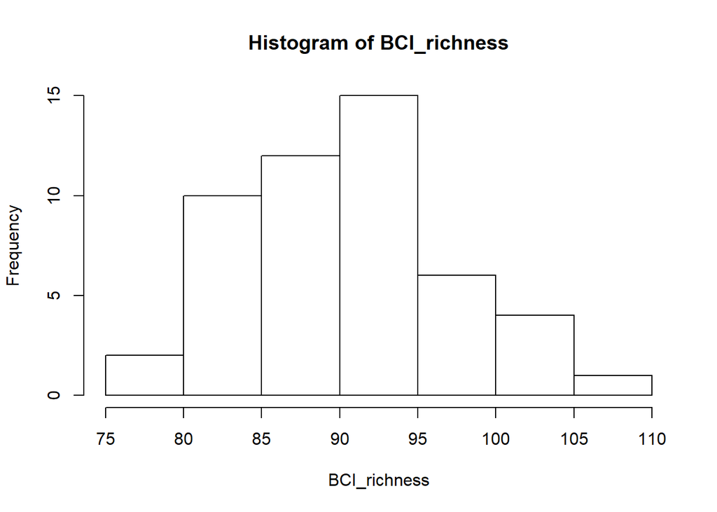

```r
BCI_richness = apply(BCI, 1, function(x) sum(x > 0))
hist(BCI_richness)
```

Look for clustering of sites with similar richness together. There is not too much clustering, but the pink dots tend to be near each other.

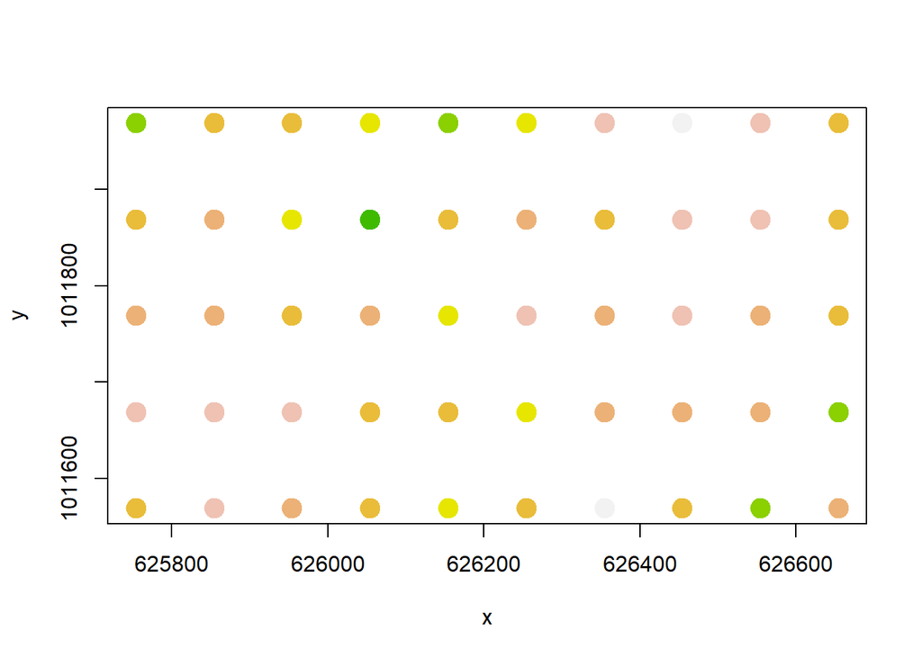

```r
col_brks = hist(BCI_richness, plot=F)$breaks
col_indices = as.numeric(cut(BCI_richness, col_brks))
cols = rev(terrain.colors(length(col_brks)))
plot(BCI_xy, cex=2, pch=19, col=cols[col_indices])
```

Find the median abundance of the species.

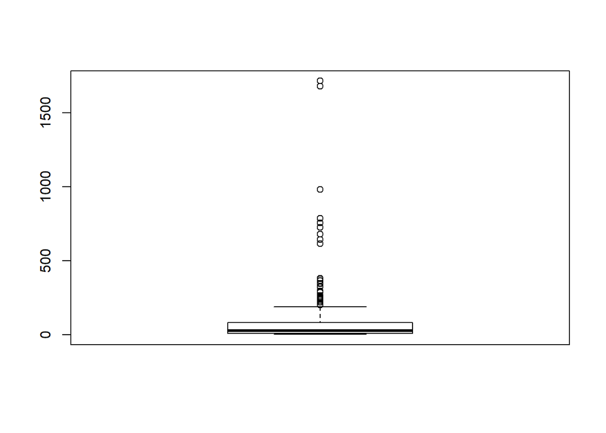

```r
sum_species = sapply(BCI, sum)

boxplot(sum_species)
```

```r
quantile(sum_species, 0.50)
```

```
## 50%
##  25
```

Declare those with abundance less than the median as rare (except ones with only one individual because single samples cannot be analyzed for spatial patterns).

```r
rare_sp = BCI

for (i in ncol(BCI):1) {
  sp_abundance = sum(BCI[ , i])
  if(sp_abundance > 25 | sp_abundance == 1) {
    print(colnames(BCI)[i])
    rare_sp = rare_sp[, -i]
  }
}
```

```
## [1] "Zanthoxylum.setulosum"
## [1] "Zanthoxylum.panamense"
## [1] "Zanthoxylum.juniperinum"
## [1] "Zanthoxylum.ekmanii"
## [1] "Xylopia.macrantha"
## [1] "Vismia.baccifera"
## [1] "Virola.surinamensis"
## [1] "Virola.sebifera"
## [1] "Unonopsis.pittieri"
## [1] "Turpinia.occidentalis"
## [1] "Trophis.racemosa"
## [1] "Trophis.caucana"
## [1] "Triplaris.cumingiana"
## [1] "Trichospermum.galeottii"
## [1] "Trichilia.tuberculata"
```

[output cut: 116 more lines]

```r
ncol(rare_sp)
```

```
## [1] 94
```

Declare those species with an abundance higher than the median as common.

```r
common_sp = BCI

for (i in ncol(BCI):1) {
  sp_abundance = sum(BCI[ , i])
  if(sp_abundance <= 25) {
    print(colnames(BCI)[i])
    common_sp = common_sp[, -i]
  }
}
```

```
## [1] "Zuelania.guidonia"
## [1] "Zanthoxylum.setulosum"
## [1] "Vochysia.ferruginea"
## [1] "Vismia.baccifera"
## [1] "Virola.multiflora"
## [1] "Trichospermum.galeottii"
## [1] "Trichanthera.gigantea"
## [1] "Trema.micrantha"
## [1] "Tocoyena.pittieri"
## [1] "Thevetia.ahouai"
## [1] "Theobroma.cacao"
## [1] "Tetrathylacium.johansenii"
## [1] "Talisia.princeps"
## [1] "Talisia.nervosa"
## [1] "Spachea.membranacea"
```

[output cut: 98 more lines]

```r
ncol(common_sp)
```

```
## [1] 112
```

```r
common_sp[,1:3]
```

```
##    Adelia.triloba Alchornea.costaricensis Allophylus.psilospermus
## 1               0                       2                       0
## 2               0                       1                       0
## 3               0                       2                       0
## 4               3                      18                       0
## 5               1                       3                       1
## 6               0                       2                       0
## 7               0                       0                       0
## 8               0                       2                       0
## 9               5                       2                       0
## 10              0                       2                       0
## 11              0                      10                       0
## 12              1                       3                       2
## 13              1                       1                       1
## 14              0                       4                       0
```

[output cut: 36 more lines]

```r
rare_sp[,1:3]
```

```
##    Vachellia.melanoceras Acalypha.diversifolia Aegiphila.panamensis
## 1                      0                     0                    0
## 2                      0                     0                    0
## 3                      0                     0                    0
## 4                      0                     0                    0
## 5                      0                     0                    1
## 6                      0                     0                    0
## 7                      0                     0                    1
## 8                      0                     0                    0
## 9                      0                     0                    0
## 10                     0                     0                    1
## 11                     0                     0                    0
## 12                     0                     0                    1
## 13                     0                     0                    1
## 14                     0                     0                    0
```

[output cut: 36 more lines]

```r
xy_dist = dist(BCI_xy)
comm_dist = vegdist(common_sp)
rare_dist = vegdist(rare_sp)
```

The nonlinear model shows a stronger influence of spatial distribution at shorter distances. Generally, since the slope is not equal to 0, there appears to be some evidence of spatial dependence for the common species.

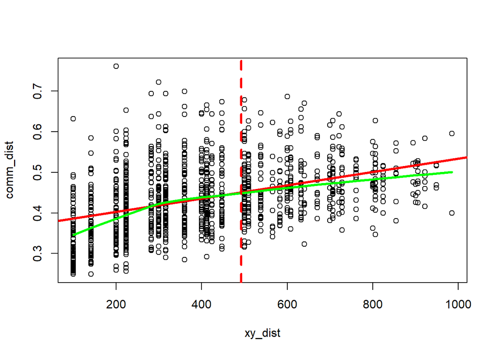

```r
max_dist = max(xy_dist) / 2
plot(xy_dist, comm_dist)
abline(lm(comm_dist ~ xy_dist), lwd=3, col='red')
lines(lowess(xy_dist, comm_dist), lwd=3, col='green')
abline(v = max_dist, col='red', lwd=3, lty=2)
```

Both the linear and nonlinear models for the rare species are flatter than the lines for the common species. This indicates that variance does not increase as much with distance, and therefore, there is less spatial dependence. The nonlinear model shows that at further distances there may be no spatial dependence.

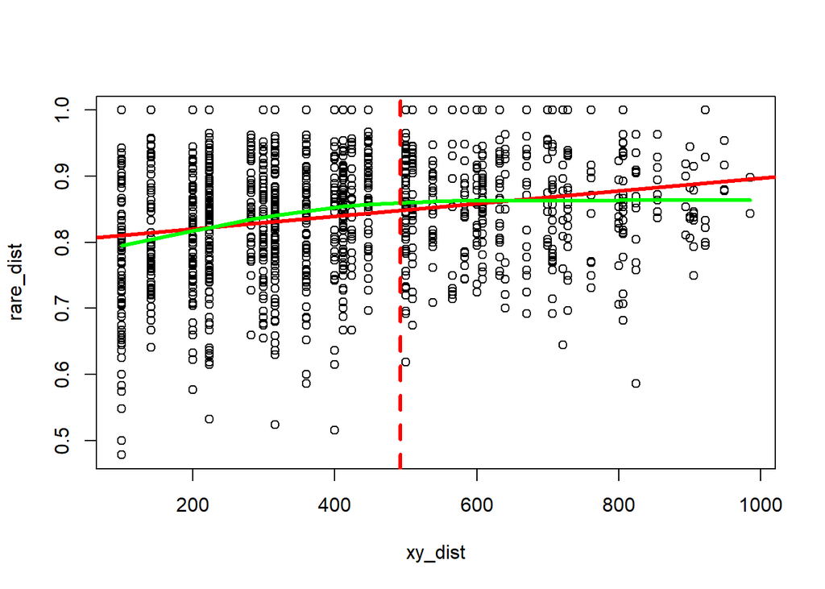

```r
plot(xy_dist, rare_dist)
abline(lm(rare_dist ~ xy_dist), lwd=3, col='red')
lines(lowess(xy_dist, rare_dist), lwd=3, col='green')
abline(v = max_dist, col='red', lwd=3, lty=2)
```

The mantel statistic can be used to demonstrate the same trend that was seen above. It is based on the linear models shown above. It uses random permutations to create a null model and compares the observed distances to that model. In this case the mantel statistic is 0.405 for the common species.

```r
comm_mantel = mantel(xy_dist, comm_dist)
comm_mantel
```

```
##
## Mantel statistic based on Pearson's product-moment correlation
##
## Call:
## mantel(xdis = xy_dist, ydis = comm_dist)
##
## Mantel statistic r: 0.4045
##       Significance: 0.001
##
## Upper quantiles of permutations (null model):
##    90%    95%  97.5%    99%
## 0.0653 0.0864 0.1124 0.1309
## Permutation: free
## Number of permutations: 999
```

For the rare species, the mantel statistic is only 0.2259. Since this is closer to 0, as it would be if it were the same as the null model, there is less spatial dependence present for the rare species in this dataset.

```r
rare_mantel = mantel(xy_dist, rare_dist)
rare_mantel
```

```
##
## Mantel statistic based on Pearson's product-moment correlation
##
## Call:
## mantel(xdis = xy_dist, ydis = rare_dist)
##
## Mantel statistic r: 0.2259
##       Significance: 0.001
##
## Upper quantiles of permutations (null model):
##    90%    95%  97.5%    99%
## 0.0496 0.0641 0.0802 0.1012
## Permutation: free
## Number of permutations: 999
```

This can be further investigated with a correlogram analysis.

```r
comm_corlog = mantel.correlog(comm_dist, xy_dist)
rare_corlog = mantel.correlog(rare_dist, xy_dist)

comm_corlog
```

```
##
## Mantel Correlogram Analysis
##
## Call:
##
## mantel.correlog(D.eco = comm_dist, D.geo = xy_dist)
##
##         class.index     n.dist Mantel.cor Pr(Mantel) Pr(corrected)
## D.cl.1   136.870241 144.000000   0.181351      0.001         0.001 ***
## D.cl.2   210.610723 376.000000   0.131850      0.001         0.002 **
## D.cl.3   284.351204 390.000000  -0.018823      0.250         0.250
## D.cl.4   358.091686 148.000000  -0.031061      0.083         0.166
## D.cl.5   431.832168 372.000000  -0.051485      0.038         0.114
## D.cl.6   505.572649 266.000000  -0.085035      0.001         0.006 **
## D.cl.7   579.313131 168.000000         NA         NA            NA
## D.cl.8   653.053613 100.000000         NA         NA            NA
## D.cl.9   726.794094 154.000000         NA         NA            NA
## D.cl.10  800.534576  88.000000         NA         NA            NA
## D.cl.11  874.275058  50.000000         NA         NA            NA
## D.cl.12  948.015539  24.000000         NA         NA            NA
## ---
## Signif. codes:  0 '***' 0.001 '**' 0.01 '*' 0.05 '.' 0.1 ' ' 1
```

```r
rare_corlog
```

```
##
## Mantel Correlogram Analysis
##
## Call:
##
## mantel.correlog(D.eco = rare_dist, D.geo = xy_dist)
##
##         class.index     n.dist Mantel.cor Pr(Mantel) Pr(corrected)
## D.cl.1   136.870241 144.000000   0.070186      0.010         0.010 **
## D.cl.2   210.610723 376.000000   0.089321      0.002         0.004 **
## D.cl.3   284.351204 390.000000   0.016615      0.261         0.261
## D.cl.4   358.091686 148.000000   0.012573      0.323         0.522
## D.cl.5   431.832168 372.000000  -0.066762      0.011         0.040 *
## D.cl.6   505.572649 266.000000  -0.100849      0.001         0.006 **
## D.cl.7   579.313131 168.000000         NA         NA            NA
## D.cl.8   653.053613 100.000000         NA         NA            NA
## D.cl.9   726.794094 154.000000         NA         NA            NA
## D.cl.10  800.534576  88.000000         NA         NA            NA
## D.cl.11  874.275058  50.000000         NA         NA            NA
## D.cl.12  948.015539  24.000000         NA         NA            NA
## ---
## Signif. codes:  0 '***' 0.001 '**' 0.01 '*' 0.05 '.' 0.1 ' ' 1
```

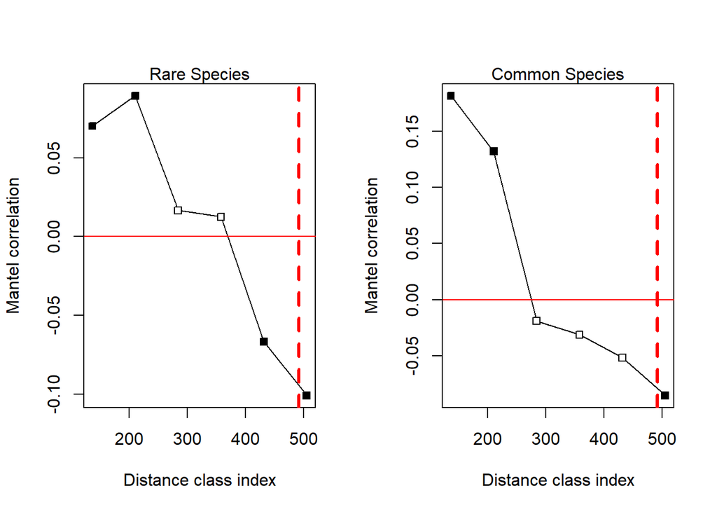

```r
par(mfrow=c(1,2))
plot(rare_corlog)
mtext(side=3, 'Rare Species')
abline(v = max_dist, col='red', lwd=3, lty=2)

plot(comm_corlog)
mtext(side=3, 'Common Species')
abline(v = max_dist, col='red', lwd=3, lty=2)
```

## Question 2

A matrix is made with just the explanatory and response species.

```r
predict_sp = BCI

for (i in ncol(BCI):1) {
  sp_abundance = sum(BCI[ , i])
  if(colnames(BCI)[i] != "Cordia.lasiocalyx" &
     colnames(BCI)[i] != "Hirtella.triandra" &
     colnames(BCI)[i] != "Picramnia.latifolia" &
     colnames(BCI)[i] != "Quassia.amara" &
     colnames(BCI)[i] != "Tabernaemontana.arborea" &
     colnames(BCI)[i] != "Trattinnickia.aspera" &
     colnames(BCI)[i] != "Xylopia.macrantha" &
     colnames(BCI)[i] != "Drypetes.standleyi") {

    predict_sp = predict_sp[, -i]
  }
}

colnames(predict_sp)
```

```
## [1] "Cordia.lasiocalyx"       "Drypetes.standleyi"
## [3] "Hirtella.triandra"       "Picramnia.latifolia"
## [5] "Quassia.amara"           "Tabernaemontana.arborea"
## [7] "Trattinnickia.aspera"    "Xylopia.macrantha"
```

A dataframe is made that combines these species’ abundance data with the location data for the sites. A generalized least squares model is made with all of the species as explantory variables. The model does not appear to be the best fit because the AIC value is relatively high at 307. Two of the explanatory species have significant p-values, but *Xylopia macrantha* has the smallest at 0.0006, (*Cordia lasiocalyx* has a p-value of 0.0415) so that is the species used as the explanatory variable in the individual model.

```r
spatial_data = data.frame(predict_sp, BCI_xy)

sp_gls = gls(Drypetes.standleyi~ Cordia.lasiocalyx +  Hirtella.triandra + Picramnia.latifolia + Quassia.amara + Tabernaemontana.arborea + Trattinnickia.aspera + Xylopia.macrantha, data = spatial_data)

summary(sp_gls)
```

```
## Generalized least squares fit by REML
##   Model: Drypetes.standleyi ~ Cordia.lasiocalyx + Hirtella.triandra +      Picramnia.latifolia + Quassia.amara + Tabernaemontana.arborea +      Trattinnickia.aspera + Xylopia.macrantha
##   Data: spatial_data
##        AIC      BIC    logLik
##   307.1163 322.7554 -144.5582
##
## Coefficients:
##                             Value Std.Error   t-value p-value
## (Intercept)             -1.051752 2.1175346 -0.496687  0.6220
## Cordia.lasiocalyx        0.428920 0.2039316  2.103255  0.0415
## Hirtella.triandra        0.122279 0.0802638  1.523462  0.1351
## Picramnia.latifolia      0.662259 0.6358905  1.041468  0.3036
## Quassia.amara            4.085661 2.2842770  1.788602  0.0809
## Tabernaemontana.arborea -0.249725 0.1491192 -1.674667  0.1014
## Trattinnickia.aspera     1.349323 0.7147412  1.887848  0.0660
## Xylopia.macrantha        0.548832 0.1468772  3.736672  0.0006
##
##  Correlation:
##                         (Intr) Crd.ls Hrtll. Pcrmn. Qss.mr Tbrnm. Trttn.
## Cordia.lasiocalyx       -0.618
## Hirtella.triandra       -0.212 -0.354
## Picramnia.latifolia      0.025 -0.019 -0.381
## Quassia.amara            0.163 -0.378  0.307 -0.302
## Tabernaemontana.arborea -0.708  0.245  0.163 -0.113  0.148
## Trattinnickia.aspera    -0.139  0.187 -0.311  0.308 -0.708 -0.144
## Xylopia.macrantha       -0.140 -0.125  0.156 -0.463  0.314  0.279 -0.294
##
## Standardized residuals:
##         Min          Q1         Med          Q3         Max
## -1.87708765 -0.42701500 -0.04032793  0.23615609  3.38768871
##
## Residual standard error: 4.539713
## Degrees of freedom: 50 total; 42 residual
```

A model for the abundance of *Drypetes standleyi* is made with only the abundance of *Xylopia macrantha* as the explanatory variable. The AIC increased to 338, so this model is an even worse fit than the one with all of the species included.

```r
xylopia_gls= gls(Drypetes.standleyi~  Xylopia.macrantha, data = spatial_data)

summary(xylopia_gls)
```

```
## Generalized least squares fit by REML
##   Model: Drypetes.standleyi ~ Xylopia.macrantha
##   Data: spatial_data
##        AIC      BIC    logLik
##   338.2919 343.9055 -166.1459
##
## Coefficients:
##                      Value Std.Error  t-value p-value
## (Intercept)       3.285252 1.0990108 2.989281  0.0044
## Xylopia.macrantha 0.844318 0.1804326 4.679407  0.0000
##
##  Correlation:
##                   (Intr)
## Xylopia.macrantha -0.47
##
## Standardized residuals:
##        Min         Q1        Med         Q3        Max
## -1.3044324 -0.4788137 -0.3103771  0.1041720  3.9616489
##
## Residual standard error: 6.861233
## Degrees of freedom: 50 total; 48 residual
```

A Variogram of the model is plotted. This takes into account distance and plots variance in the data versus the distance between the sites. This line is showing very little spatial trend.

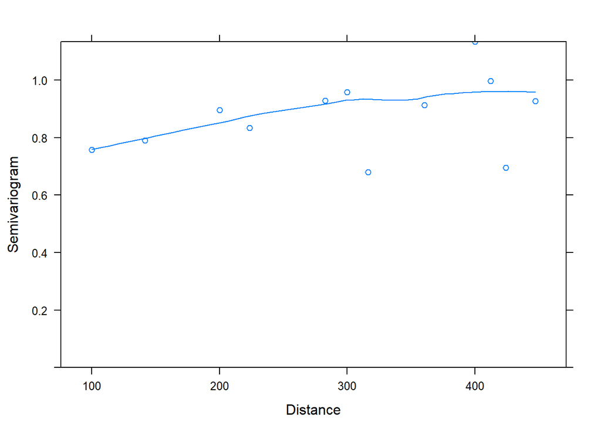

```r
plot(Variogram(sp_gls, form = ~ x + y, maxDist = max_dist))
```

The model is adjusted using the exponential error structure. This model appears to show a much greater spatial dependence in the residuals. While the slope is actually greater, the difference between this and the previous graph is not as drastic as it seems when you account for the scale.

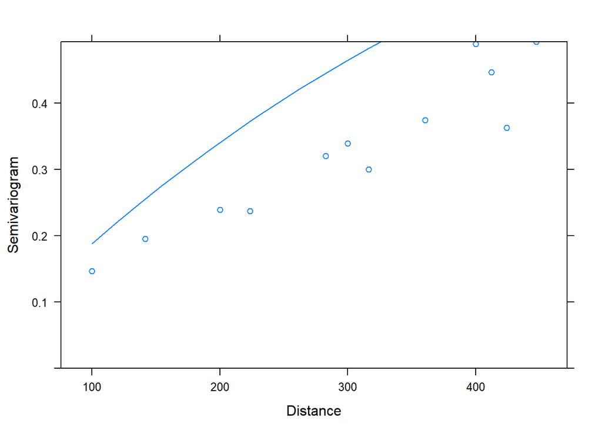

```r
sp_exp = update(sp_gls, corr=corExp(form=~x + y))

plot(Variogram(sp_exp, maxDist = max_dist))
```

Since this model does not appear to fit the residuals well, and there appears to be a nugget of 0.2, the model was further adjusted to include a nugget. This seems to be a better fit, and the slope is even smaller, showing little spatial dependence once the spatial error term is included.

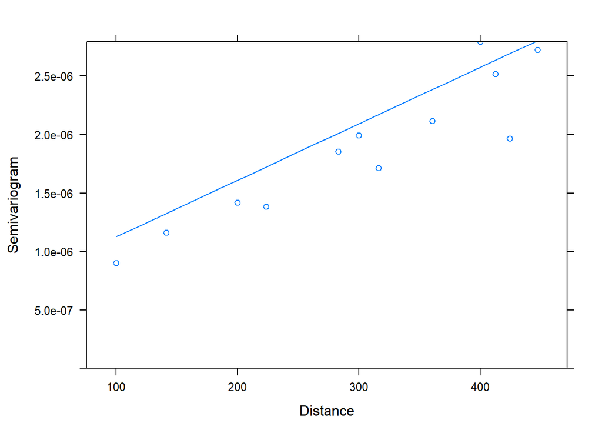

```r
sp_exp = update(sp_gls, corr=corExp(form=~x + y, nugget = TRUE))

plot(Variogram(sp_exp, maxDist = max_dist))
```

With the individual model, there is much greater spatial dependence initially than in initial model with all species.

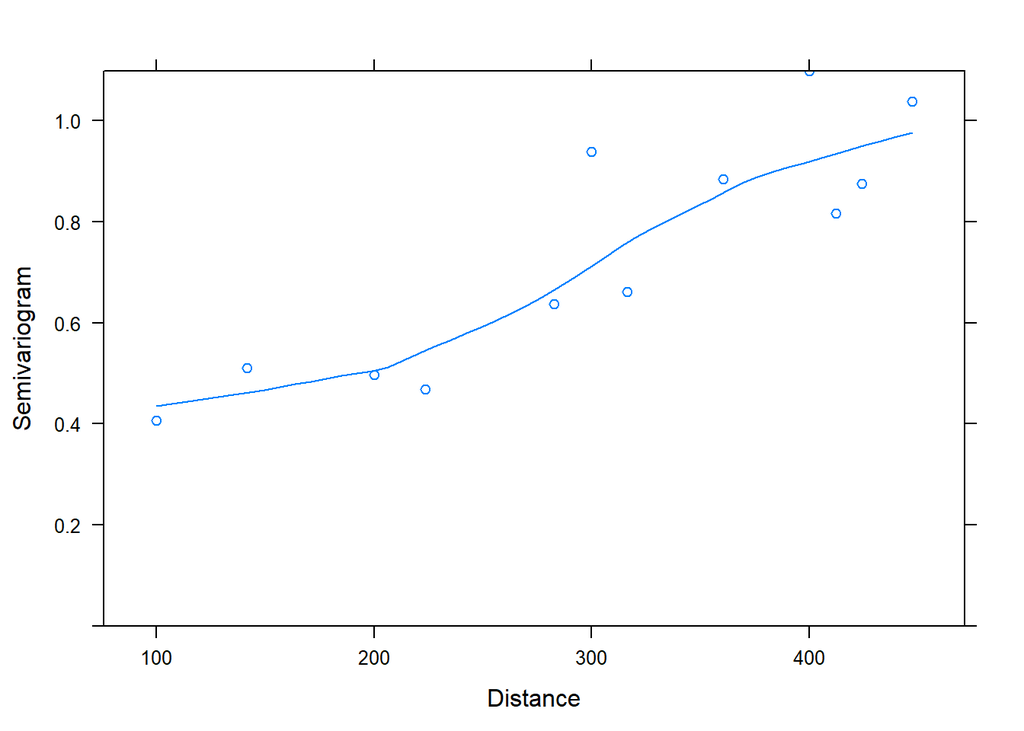

```r
plot(Variogram(xylopia_gls, form= ~x + y, maxDist = max_dist))
```

The model is adjusted using an exponential error structure. This time with no nugget since the values on the y-axis are so close to zero. Adding the spatial error term seems to have accounted for some of the spatial dependence of the residuals.

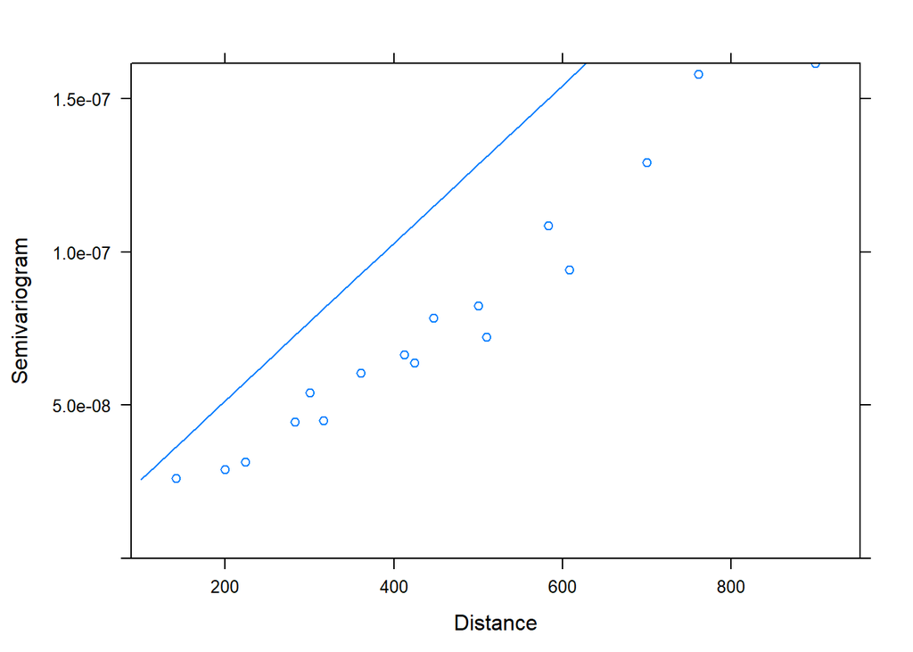

```r
xylopia_exp = update(xylopia_gls,
                     corr=corExp(form=~x + y))

plot(Variogram(xylopia_exp))
```

The AIC decreased when the spatial error term was added, so the model with all of the species was improved by this addition.

```r
anova(sp_gls, sp_exp, test = F)
```

```
##        Model df      AIC      BIC    logLik
## sp_gls     1  9 307.1163 322.7554 -144.5582
## sp_exp     2 11 301.9592 321.0735 -139.9796
```

An even more clear decrease in the AIC indicates that the individual model fits much better when the spatial error term is included, but still not as good as the model with all of the species and the spatial error term.

```r
anova(xylopia_gls, xylopia_exp)
```

```
##             Model df      AIC      BIC    logLik   Test  L.Ratio p-value
## xylopia_gls     1  3 338.2919 343.9055 -166.1459
## xylopia_exp     2  4 308.6325 316.1173 -150.3163 1 vs 2 31.65933  <.0001
```

The spatial error term did not have a large impact on all of the coefficients. However, the coefficients for *Cordia lasiocalyx*, *Hirtella triandra*, *Picramnia latifolia*, *Quassia amara*, and *Tabernaemontana arborea* did decrease a lot when the spatial error term was added.

```r
summary(sp_gls)
```

```
## Generalized least squares fit by REML
##   Model: Drypetes.standleyi ~ Cordia.lasiocalyx + Hirtella.triandra +      Picramnia.latifolia + Quassia.amara + Tabernaemontana.arborea +      Trattinnickia.aspera + Xylopia.macrantha
##   Data: spatial_data
##        AIC      BIC    logLik
##   307.1163 322.7554 -144.5582
##
## Coefficients:
##                             Value Std.Error   t-value p-value
## (Intercept)             -1.051752 2.1175346 -0.496687  0.6220
## Cordia.lasiocalyx        0.428920 0.2039316  2.103255  0.0415
## Hirtella.triandra        0.122279 0.0802638  1.523462  0.1351
## Picramnia.latifolia      0.662259 0.6358905  1.041468  0.3036
## Quassia.amara            4.085661 2.2842770  1.788602  0.0809
## Tabernaemontana.arborea -0.249725 0.1491192 -1.674667  0.1014
## Trattinnickia.aspera     1.349323 0.7147412  1.887848  0.0660
## Xylopia.macrantha        0.548832 0.1468772  3.736672  0.0006
##
##  Correlation:
##                         (Intr) Crd.ls Hrtll. Pcrmn. Qss.mr Tbrnm. Trttn.
## Cordia.lasiocalyx       -0.618
## Hirtella.triandra       -0.212 -0.354
## Picramnia.latifolia      0.025 -0.019 -0.381
## Quassia.amara            0.163 -0.378  0.307 -0.302
## Tabernaemontana.arborea -0.708  0.245  0.163 -0.113  0.148
## Trattinnickia.aspera    -0.139  0.187 -0.311  0.308 -0.708 -0.144
## Xylopia.macrantha       -0.140 -0.125  0.156 -0.463  0.314  0.279 -0.294
##
## Standardized residuals:
##         Min          Q1         Med          Q3         Max
## -1.87708765 -0.42701500 -0.04032793  0.23615609  3.38768871
##
## Residual standard error: 4.539713
## Degrees of freedom: 50 total; 42 residual
```

```r
summary(sp_exp)
```

```
## Generalized least squares fit by REML
##   Model: Drypetes.standleyi ~ Cordia.lasiocalyx + Hirtella.triandra +      Picramnia.latifolia + Quassia.amara + Tabernaemontana.arborea +      Trattinnickia.aspera + Xylopia.macrantha
##   Data: spatial_data
##        AIC      BIC    logLik
##   301.9592 321.0735 -139.9796
##
## Correlation Structure: Exponential spatial correlation
##  Formula: ~x + y
##  Parameter estimate(s):
##        range       nugget
## 2.069876e+08 6.423682e-07
##
## Coefficients:
##                              Value Std.Error   t-value p-value
## (Intercept)              3.0501207  3486.910  0.000875  0.9993
## Cordia.lasiocalyx        0.1426665     0.190  0.752751  0.4558
## Hirtella.triandra       -0.0017716     0.090 -0.019602  0.9845
## Picramnia.latifolia      0.2863333     0.527  0.542880  0.5901
## Quassia.amara            1.3263608     1.937  0.684817  0.4972
## Tabernaemontana.arborea  0.0407531     0.140  0.292086  0.7717
## Trattinnickia.aspera     1.8170752     0.573  3.171304  0.0028
## Xylopia.macrantha        0.4086698     0.154  2.659323  0.0110
##
##  Correlation:
##                         (Intr) Crd.ls Hrtll. Pcrmn. Qss.mr Tbrnm. Trttn.
## Cordia.lasiocalyx        0.000
## Hirtella.triandra       -0.001 -0.098
## Picramnia.latifolia      0.000  0.017 -0.360
## Quassia.amara            0.000 -0.292  0.344 -0.193
## Tabernaemontana.arborea  0.000 -0.020  0.160 -0.197  0.088
## Trattinnickia.aspera     0.000  0.165 -0.276  0.255 -0.655 -0.036
## Xylopia.macrantha        0.000 -0.066 -0.037 -0.048  0.306  0.140 -0.183
##
## Standardized residuals:
##           Min            Q1           Med            Q3           Max
## -0.0025251382 -0.0014891171 -0.0010582565  0.0002851465  0.0053085949
##
## Residual standard error: 3486.914
## Degrees of freedom: 50 total; 42 residual
```

When the spatial error term was added the *Xylopia macrantha* coefficient did decrease a lot (from 0.844 to 0.292). This large decrease indicates, like the drop in AIC value and the variograms, that there was more spatial dependence in the residuals in the individual model.

```r
summary(xylopia_gls)
```

```
## Generalized least squares fit by REML
##   Model: Drypetes.standleyi ~ Xylopia.macrantha
##   Data: spatial_data
##        AIC      BIC    logLik
##   338.2919 343.9055 -166.1459
##
## Coefficients:
##                      Value Std.Error  t-value p-value
## (Intercept)       3.285252 1.0990108 2.989281  0.0044
## Xylopia.macrantha 0.844318 0.1804326 4.679407  0.0000
##
##  Correlation:
##                   (Intr)
## Xylopia.macrantha -0.47
##
## Standardized residuals:
##        Min         Q1        Med         Q3        Max
## -1.3044324 -0.4788137 -0.3103771  0.1041720  3.9616489
##
## Residual standard error: 6.861233
## Degrees of freedom: 50 total; 48 residual
```

```r
summary(xylopia_exp)
```

```
## Generalized least squares fit by REML
##   Model: Drypetes.standleyi ~ Xylopia.macrantha
##   Data: spatial_data
##        AIC      BIC    logLik
##   308.6325 316.1173 -150.3163
##
## Correlation Structure: Exponential spatial correlation
##  Formula: ~x + y
##  Parameter estimate(s):
##      range
## 3889167290
##
## Coefficients:
##                       Value Std.Error   t-value p-value
## (Intercept)       13.820272 28257.965 0.0004891  0.9996
## Xylopia.macrantha  0.292271     0.171 1.7064090  0.0944
##
##  Correlation:
##                   (Intr)
## Xylopia.macrantha 0
##
## Standardized residuals:
##           Min            Q1           Med            Q3           Max
## -0.0005304471 -0.0004890753 -0.0004182988 -0.0002590516  0.0006842074
##
## Residual standard error: 28257.97
## Degrees of freedom: 50 total; 48 residual
```

Overall, the spatial error term was important for both the model with all of the species as explanatory variables and the one with only *Xylopia* as the explanatory variable, as was evidenced from the decrease in AIC value and many of the coefficients. However, there was more influence for the *Xylopia* only model because the residuals of that model had more spatial dependence, which makes sense because one species is going to show more spatial dependence than multiple species explaining a response together. Multiple species cover more sites than a single species, so there is less likely to be clustering. The lowest AIC was 301, so the model with the best fit was the one with all of the species included and the spatial error term (sp_exp), but that was still not a great model of the abundance of *Drypetes standleyi*.